# Señales Periódicas y No periódicas

## SISTEMAS Y SEÑALES

### Ingenieria de Telecomunicaciones

### Universidad Pontificia Bolivariana

### Por: Jose R. Zapata - https://joserzapata.github.io/

**joser.zapata@upb.edu.co**

```python
# Script para ver y ocultar el codigo del jupyter
from IPython.display import HTML

HTML('''<script>
  function code_toggle() {
    if (code_shown){
      $('div.input').hide('500');
      $('#toggleButton').val('Ver el Codigo de Python')
    } else {
      $('div.input').show('500');
      $('#toggleButton').val('Ocultar el Codigo')
    }
    code_shown = !code_shown
  }

  $( document ).ready(function(){
    code_shown=false;
    $('div.input').hide()
  });
</script>
<form action="javascript:code_toggle()">
<input type="submit" id="toggleButton" value="Ver el Codigo de Python"></form>''')
```

# Señales Periodicas

Las señales periodicas continuas $x(t)$ cumplen la caracteristica que existe un valor $T$ tal que: \begin{equation} \large x(t) = x(t+T) \:\:\:\:\:\: \forall t \in \mathbb{R}. \end{equation}

**Propiedad:** No cambia para un corrimiento del tiempo $T$

## Señal continua

Si $x(t)$ es continua entonces: \begin{equation} \large x(t) = x(t+m \cdot T) \:\:\:\:\:\: \forall m \in \mathbb{Z} \end{equation}

El valor de T es conocido como el periodo de la señal.

La relación entre el periodo T y la frecuencia f se da por la ecuacion:

\begin{equation} \large f = \frac{1}{T}[=]\frac{1}{seg}\text{Hz} \end{equation}\begin{equation} \large\omega = 2 \pi f = \frac{2 \pi}{T} [=]\text{rad/seg} \end{equation}

El periodo fundamental $To$ de $x(t)$ es el valor mas pequeño para el cual se cumple la ecuacion anterior.

Si $x(t) = kte$ entonces $T = Indefinido$

```python
# importar librerias de python

import sympy as sym # Libreria de operaciones matematicass simbolicas
import matplotlib.pyplot as plt

plt.style.use('bmh') # estilo de las graficas
%matplotlib inline

#sym.init_printing()

from IPython.display import Latex # para visualizar ecuaciones en jupyter
```

$\large x(t) = cos(2 \cdot t )$

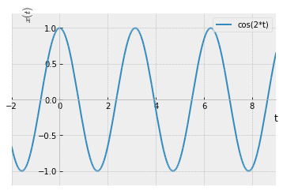

```python
# definicion de t como variable simbolica
t, omega = sym.symbols('t omega', real=True)

# Funcion en forma de triangulo
coseno = sym.cos(omega*t)

display(Latex(r'$\large x(t) = cos(2 \cdot t )$'))
# Grafica de la funcion creada
sym.plot(coseno.subs(omega, 2), (t, -2, 9),
         ylim=[-1.2, 1.2],  ylabel=r'$x(t)$', legend=True);
```

**Pregunta:** Si $w=2$ cuanto es el valor de la frecuencia en Hz?

## Señal discreta

Si $x[n]$ es discreta entonces: \begin{equation} \large x[n] = x[n+N] \:\:\:\:\:\: \forall n \in \mathbb{Z} \end{equation}

EL periodo fundamental $No$ es el valor mas pequeño

```python
import numpy as np
import matplotlib.pyplot as plt
%matplotlib inline
```

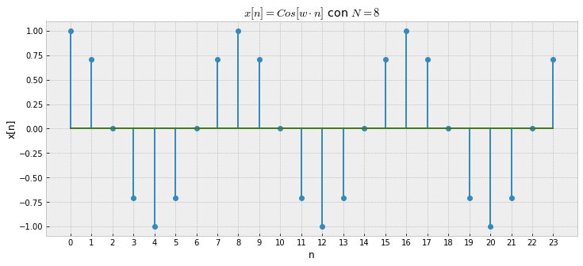

```python
plt.figure(figsize=(12, 5))
# ingreso de parámetros
N = 8
m = 3
t0 = 0

# Procedimiento
tn = m*N
w = 2*np.pi/N
n = np.arange(t0, tn, 1)
xn = np.cos(w*n)

# Salida
plt.stem(n, xn, use_line_collection=True)
plt.xlabel('n')
plt.ylabel('x[n]')
plt.title('$x[n] = Cos[w \cdot n]$ con $N = 8$')
plt.xticks(np.arange(min(n), max(n)+1, 1.0))
plt.show()
```

# Señales No Periodicas

En éste caso, los valores de la señal no se repiten para ningun valor de $T$.

También para algunos problemas se considera que $T\rightarrow \infty $.

## Señal Continua

Un ejemplo del tipo de señal es: $x(t)=t^2$

$\large x(t) = t² $

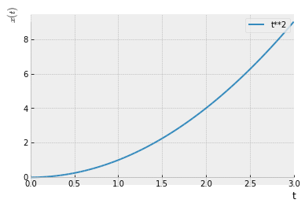

```python
# Grafica de la funcion creada
t2 = t*t
display(Latex(r'$\large x(t) = t² $'))
sym.plot(t2, (t, 0, 3), ylabel=r'$x(t)$', legend=True);
```

## Señal Discreta

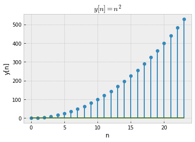

```python
yn = n**2

# SALIDA - Gráfica
plt.stem(n, yn, use_line_collection=True)
plt.xlabel('n')
plt.ylabel('y[n]')
plt.title('$y[n]=n^2$')
plt.show()
```

# Ejercicios

Realice las graficas de las siguientes funciones contínuas:

- $\large t^3$
- $\large e^t$
- $\large \frac{1}{t}$

y sus versiones discretas

- $\large n^3$
- $\large e^n$
- $\large \frac{1}{n}$

# REFERENCIAS

Oppenheim Seccion 1.2.2

**Phd. Jose R. Zapata**

- https://joserzapata.github.io/
- https://twitter.com/joserzapata
- joser.zapata@upb.edu.co